# Analyzing AQI report In US

## 1 Introduction

As the world continues to develop and urbanize, worsening environmental conditions create risks for human health. Air pollution, a mix of hazardous human made and natural substances, is one of these dangers. Inhaling these toxic substances can cause serious health issues, and knowing what the air quality will be on a given day in advance can prevent you from stepping outdoors and allow you to protect yourself better. For this reason, we chose to study AQI or Air Quality Index, a metric for measuring the level of air pollution present in the air. In this report, we will be discussing how we acquired AQI data, preprocessed it, and created and tested various algorithms to finally form a predictive model that will predict the AQI over a given month.

### 1.1 Import Libraries

```python
import pandas as pd
import numpy as np
import requests
from functools import reduce
import plotly.express as px
import plotly.graph_objects as go
from plotly.subplots import make_subplots
import seaborn as sns
import matplotlib.pyplot as plt
import warnings
warnings.filterwarnings("ignore")
```

### 1.2 Create an account to access the API and request data from the website

```python
# Create an account to access API and
email = 'tomhuasj@umd.edu'
key = 'saffroncrane66'
aqs_api = 'https://aqs.epa.gov/data/api/'
```

## 2 Data

### 2.1 Request a list of states

Here is a list of states which tells us the code of state which will be used later to query a specific data using a code number. All data in this API has a specific parameter and to access the data, we need to request those specific services variables in order to create other service requests using this API.

```python
param = {'email': email, 'key': key}
endpoint = 'list/states'
response = requests.get(f'{aqs_api}{endpoint}', param)
if response.status_code == 200:
    data = response.json()
    # Process the data as needed
    #print(data)
else:
    print(f"Error: {response.status_code}")
```

Here is a list of state code we will use in our data analysis.

```python
state_list = data['Data']
state_list_df = pd.DataFrame(state_list)
state_list_df.rename(columns={"value_represented": "State"}, inplace=True)
Options = ['New York', 'Maryland', 'New Jersey']
state_list_df[state_list_df['State'].isin(Options)]
```

|  | code | State |
| --- | --- | --- |
| 20 | 24 | Maryland |
| 30 | 34 | New Jersey |
| 32 | 36 | New York |

### 2.2 Request codes for All Major Air Pollutants

By analyzing all the parameters we can get from the API, we have find all the code number for major pollutants, including PM2.5, PM10, CO, NO2, SO2, and Ozone.  
To grab the data that is related to those major air pollutants, we need the following code numbers in order to query data from the API. The code number is required to query all those data

42101 Carbon monoxide  
42401 Sulfur dioxide  
42602 Nitrogen dioxide (NO2)  
44201 Ozone  
81102 PM10 Total 0-10um STP  
88101 PM2.5 - Local Conditions

```python
CO = 42101
SO2 = 42401
NO2 = 42602
Ozone = 44201
PM10 = 81102
PM25 = 88101
```

### 2.3 Request The Data from API

In this step, I have defined several methods which allows us to send multiple request at a time, since the API only allows us to grab data with a range of 1 years.

```python
def getData(endpoint, state, pollutant, bdate, edate):
    param = {'email': email, 'key': key, 'param': pollutant, 'bdate': bdate, 'edate':edate, 'state': state}
    response = requests.get(f'{aqs_api}{endpoint}', param)

    if response.status_code == 200:
        data = response.json()
        return data['Data']
    else:
        print(f"Error: {response.status_code}")
    return None
```

```python
def getAllData(state, bdate, edate):
    list = []
    list.append(getData(endpoint, state, CO, bdate, edate))
    list.append(getData(endpoint, state, SO2, bdate, edate))
    list.append(getData(endpoint, state, NO2, bdate, edate))
    list.append(getData(endpoint, state, Ozone, bdate, edate))
    list.append(getData(endpoint, state, PM10, bdate, edate))
    list.append(getData(endpoint, state, PM25, bdate, edate))
    return list
```

The following steps is example code to request data from NY state in 2022 for better understanding.

```python
endpoint = 'dailyData/byState'
```

```python
# list_NY_2022 = getAllData(36, 20220101, 20221231)
```

### 2.4 Data Extracting and Cleaning.

#### 2.4.1 Data for Carbon Monoxide (CO)

CO data  
I have only kept date, mean value, max value, and aqi reading.  
sample_duration column: there are two kinds of sample during 1hr and 8hr, only 8hr contains information about aqi, and 8hr estimation is better for the long run prediction.  
There should be 365 lines of data. (366 lines of data in 2020)

```python
def clean_data_CO(df):
    cols = ['sample_duration', 'date_local', 'arithmetic_mean', 'first_max_value', 'aqi']
    df = df[cols].copy()
    df['date_local'] = pd.to_datetime(df['date_local'])
    df = df[df['sample_duration'] == '8-HR RUN AVG END HOUR']
    df = df.sort_values(by='date_local')

    # Find NaN data
    # display(df[df.isnull().any(axis=1)])
    df.drop(columns={'sample_duration'}, inplace = True)

    # get max value of first_max_value and aqi column
    t_max = df.groupby(by='date_local').max()
    df = df.groupby(by='date_local').mean()

    df.drop(columns=['first_max_value'], inplace = True)
    df['max_CO_value'] = t_max['first_max_value']
    df['CO_max_aqi'] = t_max['aqi']
    df.reset_index(inplace = True)
    df = df.rename(columns={'date_local': 'date', 'aqi': 'CO_mean_aqi', 'arithmetic_mean': 'CO_mean'})

    return df
```

#### 2.4.2 Ozone Data

In this part, we choose to only include the following pollutant standard:Ozone 8-hr 2015. We are not going to use data with 1 hour sample duration since those data will only have aqi when it is above 300  
All other standards: Ozone 8hr 1997/2008/2015 [Choose to only keep 2015 standard data]

```python
def clean_data_Ozone(df):
    cols =  ['sample_duration', 'pollutant_standard',  'date_local', 'arithmetic_mean', 'aqi', 'first_max_value']
    df = df[cols].copy()
    df = df[df['sample_duration'] == '8-HR RUN AVG BEGIN HOUR']
    df['date_local'] = pd.to_datetime(df['date_local'])
    df = df[df['pollutant_standard'] == 'Ozone 8-hour 2015']
    # Find NaN data
    #display(df[df.isnull().any(axis=1)])
    df.drop(columns={'sample_duration', 'pollutant_standard'}, inplace = True)

    # get max value of first_max_value and aqi column
    t_max = df.groupby(by='date_local').max()
    df = df.groupby(by='date_local').mean()

    df.drop(columns=['first_max_value'], inplace = True)
    df['max_O3_value'] = t_max['first_max_value']
    df['O3_max_aqi'] = t_max['aqi']
    df.reset_index(inplace = True)
    df = df.rename(columns={'date_local': 'date', 'aqi': 'O3_mean_aqi', 'arithmetic_mean': 'O3_mean'})

    return df
```

#### 2.4.3 SO2 Data

For this pollutant, we choose to only keep data with a sample during of 1 hr, with pollutant standard SO2 1-hour 2010

```python
def clean_data_SO2(df):
    cols =  ['sample_duration', 'pollutant_standard',  'date_local', 'arithmetic_mean', 'aqi', 'first_max_value']
    df = df[cols].copy()
    df['date_local'] = pd.to_datetime(df['date_local'])
    df = df[df['pollutant_standard'] == 'SO2 1-hour 2010']
    # Find NaN data
    #display(df[df.isnull().any(axis=1)])
    df.drop(columns={'sample_duration', 'pollutant_standard'}, inplace = True)

    # get max value of first_max_value and aqi column
    t_max = df.groupby(by='date_local').max()
    df = df.groupby(by='date_local').mean()

    df.drop(columns=['first_max_value'], inplace = True)
    df['max_SO2_value'] = t_max['first_max_value']
    df['SO2_max_aqi'] = t_max['aqi']
    df.reset_index(inplace = True)
    df = df.rename(columns={'date_local': 'date', 'aqi': 'SO2_mean_aqi', 'arithmetic_mean': 'SO2_mean'})

    return df
```

#### 2.4.4 NO2 Data

For the measurement of NO2, there are two different pollutant standards: NO2 annual 1971 and NO2 1-hour 2010. For the measurement part, we choose the second one as our pollutant standard for NO2.

```python
def clean_data_NO2(df):
    cols =  ['sample_duration', 'pollutant_standard',  'date_local', 'arithmetic_mean', 'aqi', 'first_max_value']
    df = df[cols].copy()
    df['date_local'] = pd.to_datetime(df['date_local'])
    df = df[df['pollutant_standard'] == 'NO2 1-hour 2010']
    # Find NaN data
    #display(df[df.isnull().any(axis=1)])
    df.drop(columns={'sample_duration', 'pollutant_standard'}, inplace = True)

    # get max value of first_max_value and aqi column
    t_max = df.groupby(by='date_local').max()
    df = df.groupby(by='date_local').mean()

    df.drop(columns=['first_max_value'], inplace = True)
    df['max_NO2_value'] = t_max['first_max_value']
    df['NO2_max_aqi'] = t_max['aqi']
    df.reset_index(inplace = True)
    df = df.rename(columns={'date_local': 'date', 'aqi': 'NO2_mean_aqi', 'arithmetic_mean': 'NO2_mean'})

    return df
```

#### 2.4.5 PM10 and PM2.5 Data

For both of those pollutants, they have only one pollutant standard. For the PM10 data, we are not able to get a data for each day, since it is not measured daily, and it is also not a major air pollutant most of the time. We choose to exclude this part of data in our following sections.

```python
def clean_data_PM10(df):
    cols =  ['sample_duration', 'pollutant_standard',  'date_local', 'arithmetic_mean', 'aqi', 'first_max_value']
    df = df[cols].copy()
    df['date_local'] = pd.to_datetime(df['date_local'])
    df.drop(columns={'sample_duration', 'pollutant_standard'}, inplace = True)

    t_max = df.groupby(by='date_local').max()
    df = df.groupby(by='date_local').mean()

    df.drop(columns=['first_max_value'], inplace = True)
    df['max_PM10_value'] = t_max['first_max_value']
    df['PM10_max_aqi'] = t_max['aqi']
    df.reset_index(inplace = True)
    df = df.rename(columns={'date_local': 'date', 'aqi': 'PM10_mean_aqi', 'arithmetic_mean': 'PM10_mean'})

    return df
```

```python
def clean_data_PM25(df):
    cols =  ['sample_duration', 'pollutant_standard',  'date_local', 'arithmetic_mean', 'aqi', 'first_max_value']
    df = df[cols].copy()
    df['date_local'] = pd.to_datetime(df['date_local'])
    df.dropna(inplace=True)
    df = df[df['pollutant_standard'] == 'PM25 24-hour 2012']
    df.drop(columns={'sample_duration', 'pollutant_standard'}, inplace = True)

    t_max = df.groupby(by='date_local').max()
    df = df.groupby(by='date_local').mean()

    df.drop(columns=['first_max_value'], inplace = True)
    df['max_PM25_value'] = t_max['first_max_value']
    df['PM25_max_aqi'] = t_max['aqi']
    df.reset_index(inplace = True)
    df = df.rename(columns={'date_local': 'date', 'aqi': 'PM25_mean_aqi', 'arithmetic_mean': 'PM25_mean'})

    return df
```

```python
def get_df_list(data_list):
    list = []
    for i in range(len(data_list)):
        list.append(pd.DataFrame(data_list[i]))
    return list
```

```python
# https://stackoverflow.com/questions/38089010/merge-a-list-of-pandas-dataframes
def clean_df_list(data_list, state):
    list = []
    list.append(clean_data_CO(data_list[0]))
    list.append(clean_data_SO2(data_list[1]))
    list.append(clean_data_NO2(data_list[2]))
    list.append(clean_data_Ozone(data_list[3]))
    list.append(clean_data_PM10(data_list[4]))
    list.append(clean_data_PM25(data_list[5]))

    df = reduce(lambda x, y: x.merge(y, on='date', how='outer'), list)
    df['state'] = state
    return df
```

```python
# df_NY_2022_list = get_df_list(list_NY_2022)
# df_NY_2022 = clean_df_list(df_NY_2022_list, 'NY')
# df_NY_2022
```

Grab More Data Here

```python
# --------------------------------------------------------
# NY
# --------------------------------------------------------

# list_NY_2023 = getAllData(36, 20230101, 20231031)

# df_NY_2023_list = get_df_list(list_NY_2023)
# df_NY_2023 = clean_df_list(df_NY_2023_list, 'NY')
# # df_NY_2023

list_NY_2022 = getAllData(36, 20220101, 20221231)

df_NY_2022_list = get_df_list(list_NY_2022)
df_NY_2022 = clean_df_list(df_NY_2022_list, 'NY')
# df_NY_2022

list_NY_2021 = getAllData(36, 20210101, 20211231)

df_NY_2021_list = get_df_list(list_NY_2021)
df_NY_2021 = clean_df_list(df_NY_2021_list, 'NY')
# df_NY_2021

list_NY_2020 = getAllData(36, 20200101, 20201231)

df_NY_2020_list = get_df_list(list_NY_2020)
df_NY_2020 = clean_df_list(df_NY_2020_list, 'NY')
# df_NY_2020

list_NY_2019 = getAllData(36, 20190101, 20191231)

df_NY_2019_list = get_df_list(list_NY_2019)
df_NY_2019 = clean_df_list(df_NY_2019_list, 'NY')
# df_NY_2019

list_NY_2018 = getAllData(36, 20180101, 20181231)

df_NY_2018_list = get_df_list(list_NY_2018)
df_NY_2018 = clean_df_list(df_NY_2018_list, 'NY')
# df_NY_2018

# --------------------------------------------------------
# NJ
# --------------------------------------------------------

# list_NJ_2023 = getAllData(34, 20230101, 20231031)

# df_NJ_2023_list = get_df_list(list_NJ_2023)
# df_NJ_2023 = clean_df_list(df_NJ_2023_list, 'NJ')
# # df_NJ_2023

list_NJ_2022 = getAllData(34, 20220101, 20221231)

df_NJ_2022_list = get_df_list(list_NJ_2022)
df_NJ_2022 = clean_df_list(df_NJ_2022_list, 'NJ')
# df_NJ_2022

list_NJ_2021 = getAllData(34, 20210101, 20211231)

df_NJ_2021_list = get_df_list(list_NJ_2021)
df_NJ_2021 = clean_df_list(df_NJ_2021_list, 'NJ')
# df_NJ_2021

list_NJ_2020 = getAllData(34, 20200101, 20201231)

df_NJ_2020_list = get_df_list(list_NJ_2020)
df_NJ_2020 = clean_df_list(df_NJ_2020_list, 'NJ')
# df_NJ_2020

list_NJ_2019 = getAllData(34, 20190101, 20191231)

df_NJ_2019_list = get_df_list(list_NJ_2019)
df_NJ_2019 = clean_df_list(df_NJ_2019_list, 'NJ')
# df_NJ_2019

list_NJ_2018 = getAllData(34, 20180101, 20181231)

df_NJ_2018_list = get_df_list(list_NJ_2018)
df_NJ_2018 = clean_df_list(df_NJ_2018_list, 'NJ')
# df_NJ_2018

# --------------------------------------------------------
# MD
# --------------------------------------------------------

# list_MD_2023 = getAllData(24, 20230101, 20231031)

# df_MD_2023_list = get_df_list(list_MD_2023)
# df_MD_2023 = clean_df_list(df_MD_2023_list, 'MD')
# # df_MD_2023
list_MD_2022 = getAllData(24, 20220101, 20221231)

df_MD_2022_list = get_df_list(list_MD_2022)
df_MD_2022 = clean_df_list(df_MD_2022_list, 'MD')
# df_MD_2022

list_MD_2021 = getAllData(24, 20210101, 20211231)

df_MD_2021_list = get_df_list(list_MD_2021)
df_MD_2021 = clean_df_list(df_MD_2021_list, 'MD')
# df_MD_2021

list_MD_2020 = getAllData(24, 20200101, 20201231)

df_MD_2020_list = get_df_list(list_MD_2020)
df_MD_2020 = clean_df_list(df_MD_2020_list, 'MD')
# df_MD_2020

list_MD_2019 = getAllData(24, 20190101, 20191231)

df_MD_2019_list = get_df_list(list_MD_2019)
df_MD_2019 = clean_df_list(df_MD_2019_list, 'MD')
# df_MD_2019

list_MD_2018 = getAllData(24, 20180101, 20181231)

df_MD_2018_list = get_df_list(list_MD_2018)
df_MD_2018 = clean_df_list(df_MD_2018_list, 'MD')
# df_MD_2018

# --------------------------------------------------------
# Merging all the data
# --------------------------------------------------------



import pandas as pd

locations = ['NY', 'NJ', 'MD']
years = ['2022', '2021', '2020', '2019', '2018']

merged_dfs = []

for year in years:
    year_dfs = []
    for location in locations:
        # Construct the dataframe variable name using f-strings (formatted strings)
        df_name = f"df_{location}_{year}"
        # Get the dataframe using the variable name
        if df_name in locals():
            year_dfs.append(locals()[df_name])

    # Concatenate dataframes for each year along the rows
    merged_year_df = pd.concat(year_dfs, ignore_index=True)
    merged_dfs.append(merged_year_df)

# Concatenate the merged dataframes along the rows to get the final result
df = pd.concat(merged_dfs, ignore_index=True)

# Resetting the index if needed
df.reset_index(drop=True, inplace=True)

# Display the final merged dataframe
df.head()
```

|  | date | CO_mean | CO_mean_aqi | max_CO_value | CO_max_aqi | SO2_mean | SO2_mean_aqi | max_SO2_value | SO2_max_aqi | NO2_mean | ... | O3_max_aqi | PM10_mean | PM10_mean_aqi | max_PM10_value | PM10_max_aqi | PM25_mean | PM25_mean_aqi | max_PM25_value | PM25_max_aqi | state |
| --- | --- | --- | --- | --- | --- | --- | --- | --- | --- | --- | --- | --- | --- | --- | --- | --- | --- | --- | --- | --- | --- |
| 0 | 2022-01-01 | 0.258947 | 3.8 | 0.5 | 6.0 | 0.662500 | 6.083333 | 50.4 | 69.0 | 13.371528 | ... | 29.0 | NaN | NaN | NaN | NaN | 11.066667 | 44.333333 | 17.4 | 62.0 | NY |
| 1 | 2022-01-02 | 0.239167 | 3.5 | 0.5 | 6.0 | 0.188542 | 0.083333 | 1.6 | 1.0 | 10.164584 | ... | 39.0 | NaN | NaN | NaN | NaN | 3.090909 | 12.909091 | 6.6 | 28.0 | NY |
| 2 | 2022-01-03 | 0.211667 | 3.3 | 0.7 | 8.0 | 0.304991 | 1.166667 | 6.0 | 9.0 | 12.506287 | ... | 39.0 | NaN | NaN | NaN | NaN | 4.233333 | 17.666667 | 4.9 | 20.0 | NY |
| 3 | 2022-01-04 | 0.237941 | 3.8 | 0.5 | 6.0 | 0.398237 | 0.333333 | 1.7 | 1.0 | 18.743282 | ... | 40.0 | NaN | NaN | NaN | NaN | 6.933333 | 28.666667 | 8.9 | 37.0 | NY |
| 4 | 2022-01-05 | 0.274167 | 4.3 | 0.5 | 6.0 | 0.455556 | 1.416667 | 9.6 | 13.0 | 18.943962 | ... | 35.0 | 12.4 | 11.4 | 17.0 | 16.0 | 7.958621 | 32.551724 | 18.7 | 65.0 | NY |

5 rows × 26 columns

```python
# Creating the AQI column using the maximum standardized value of the polutants.
df['aqi'] = df[['CO_mean_aqi', 'SO2_mean_aqi', 'NO2_mean_aqi', 'O3_mean_aqi', 'PM25_mean_aqi']].max(axis = 1)
```

## 3 Visualization

```python
# Add a new column 'year' based on the 'date' column
df['year'] = df['date'].dt.year
df['month'] = df['date'].dt.month
```

```python
# Group by 'state' and 'year', and calculate the average AQI
average_aqi_by_state_year = df.groupby(['state', 'year'])['aqi'].mean().reset_index()
```

Yearly Average AQI

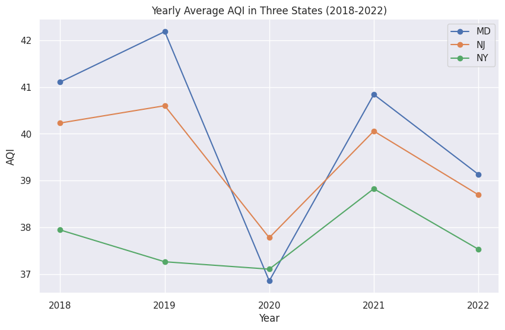

```python
# AQI OVER THE YEARS 2018-2022 PLOT (ALL STATES)

# Group by 'state' for separate plots
grouped_by_state = average_aqi_by_state_year.groupby('state')

# Plot all three trendlines on the same plot
plt.figure(figsize=(10, 6))

for state, state_df in grouped_by_state:
    plt.plot(state_df['year'], state_df['aqi'], marker='o', linestyle='-', label=f'{state}')

plt.title('Yearly Average AQI in Three States (2018-2022)')
plt.xlabel('Year')
plt.ylabel('AQI')
plt.xticks(range(average_aqi_by_state_year['year'].min(), average_aqi_by_state_year['year'].max() + 1))  # Set x-axis ticks to display years
plt.grid(True)
plt.legend()
plt.show()
```

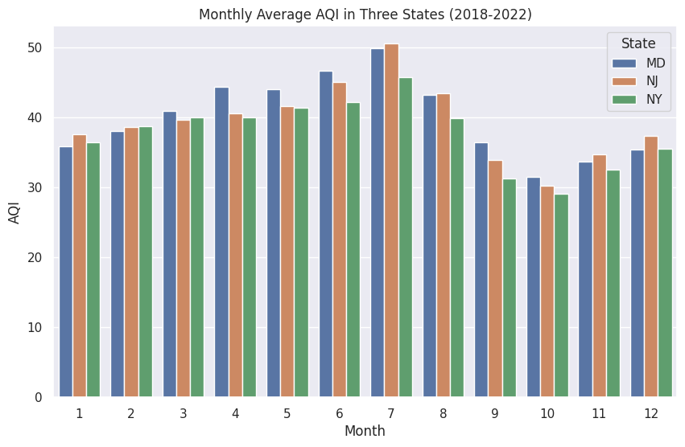

```python
# Group by 'state', 'month' and calculate the mean AQI
avg_aqi_by_state_month = df.groupby(['state', 'month'])['aqi'].mean().reset_index()

# Plot the bar graph
plt.figure(figsize=(10, 6))
sns.barplot(x='month', y='aqi', hue='state', data=avg_aqi_by_state_month)
plt.xlabel('Month')
plt.ylabel('AQI')
plt.title('Monthly Average AQI in Three States (2018-2022)')
plt.legend(title='State')
plt.show()
```

Pie chart for Percentage of good aqi reading in MD, NY, NJ

```python
def get_aqi_cate(row):
  if row['aqi'] <= 50:
    return 'good'
  elif row['aqi'] > 50 and row['aqi'] <= 100:
    return 'moderate'
  elif row['aqi'] > 100 and row['aqi'] <= 150:
    return 'Unhealthy for Sensitive Groups'
  elif row['aqi'] > 150 and row['aqi'] <= 200:
    return 'Unhealthy'
  elif row['aqi'] > 201 and row['aqi'] <= 300:
    return 'Very Unhealthy'

df_graph = df.copy()
df_graph['category'] = df_graph.apply(lambda row: get_aqi_cate(row), axis=1)
```

```python
df_graph_2022 = df_graph[df_graph['year']==2022]
df_graph_2022 = df_graph_2022[['category', 'state']]

fig = make_subplots(rows=1, cols=3, specs=[[{"type": "pie"}, {"type": "pie"}, {"type": "pie"}]], subplot_titles=['MD', 'NY', 'NJ'])
aqi_colors = ['rgb(0, 228, 0)', 'rgb(255, 255, 0)']

fig.add_trace(go.Pie(
     values=[df_graph_2022[df_graph_2022['state'] == 'MD'].value_counts()[0], df_graph_2022[df_graph_2022['state'] == 'MD'].value_counts()[1]],
     labels=['good','moderate'],
     name='MD AQI 2022',
     marker_colors=aqi_colors
     ), 1, 1)

fig.add_trace(go.Pie(
     values=[df_graph_2022[df_graph_2022['state'] == 'NY'].value_counts()[0], df_graph_2022[df_graph_2022['state'] == 'NY'].value_counts()[1]],
     labels=['good','moderate'],
     name='NY AQI 2022',
     marker_colors=aqi_colors
     ), 1, 2)

fig.add_trace(go.Pie(
     values=[df_graph_2022[df_graph_2022['state'] == 'NJ'].value_counts()[0], df_graph_2022[df_graph_2022['state'] == 'NJ'].value_counts()[1]],
     labels=['good','moderate'],
     name='NJ AQI 2022',
     marker_colors=aqi_colors
     ), 1, 3)

fig.update_traces(textinfo='value+label+percent')
#fig.update_traces(hole=.4, hoverinfo="label+percent+name")
fig.update_layout(title_text='Percentage of good aqi reading in MD, NY, NJ')
fig.show()
```

[interactive chart not shown]

```python
# Create new df without unneccessary columns
columns_to_drop = ['CO_mean', 'max_CO_value',
       'SO2_mean', 'max_SO2_value', 'NO2_mean', 'max_NO2_value', 'O3_mean', 'max_O3_value', 'PM10_mean',
       'PM10_mean_aqi', 'max_PM10_value', 'PM10_max_aqi', 'PM25_mean', 'max_PM25_value']
df_reduced = df.drop(columns=columns_to_drop)
# df_reduced.head(10)
```

A More specific graph for the AQI from 2018 to 2022

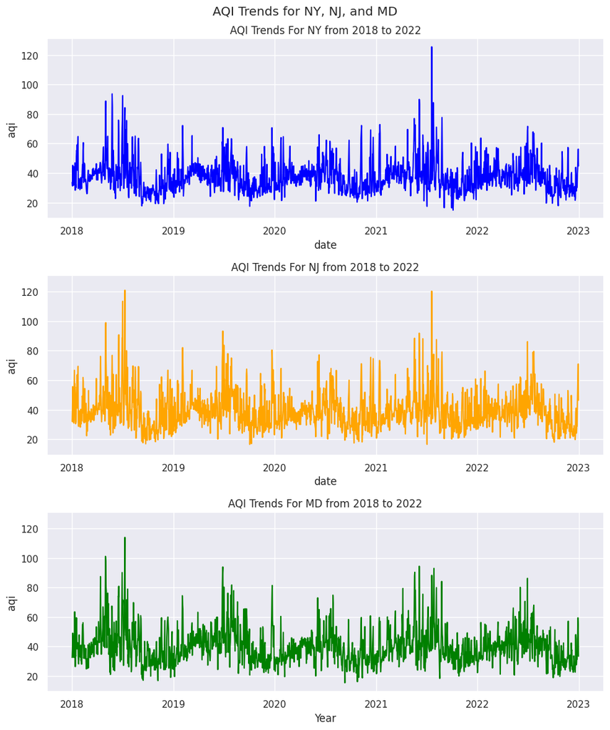

```python
sns.set()
sns.set_theme(style="darkgrid")
fig, ax = plt.subplots(3, 1, figsize=(10, 12), sharey=True)
fig.suptitle('AQI Trends for NY, NJ, and MD')
sns.lineplot(ax=ax[0], x='date', y='aqi', data=df_reduced[df_reduced['state']=='NY'], color='blue')
ax[0].set_title('AQI Trends For NY from 2018 to 2022')
sns.lineplot(ax=ax[1], x='date', y='aqi', data=df_reduced[df_reduced['state']=='NJ'], color='orange')
ax[1].set_title('AQI Trends For NJ from 2018 to 2022')
sns.lineplot(ax=ax[2], x='date', y='aqi', data=df_reduced[df_reduced['state']=='MD'], color='green')
ax[2].set_title('AQI Trends For MD from 2018 to 2022')
plt.xlabel('Year')
fig.tight_layout()
plt.show()
```

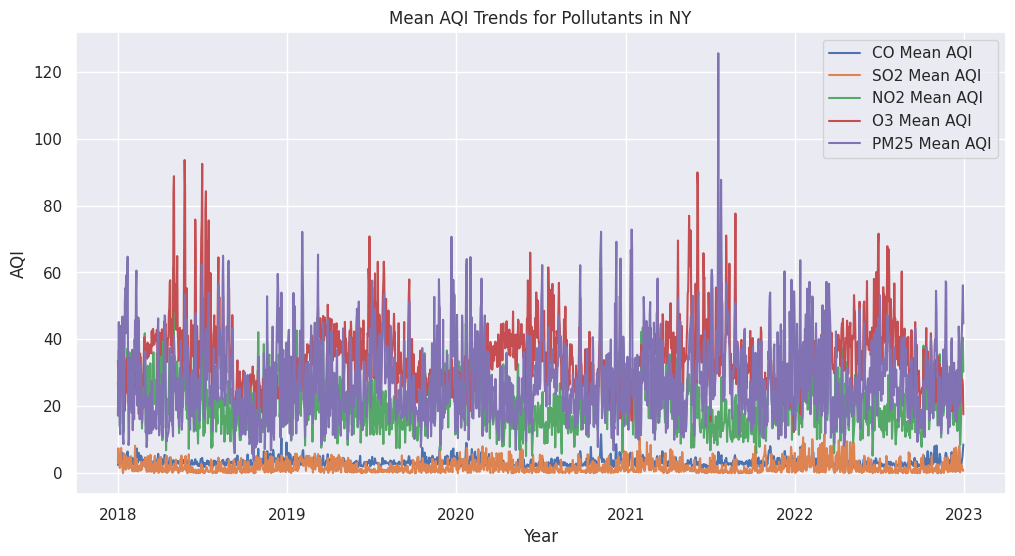

```python
# POLLUTANTS OVER TIME IN NY
# Filter data for the state of NY
df_ny = df[df['state'] == 'NY']

# Set up the plot
plt.figure(figsize=(12, 6))
sns.set_theme(style="darkgrid")

# Plot mean AQI for each pollutant
for pollutant in ['CO', 'SO2', 'NO2', 'O3', 'PM25']:
    sns.lineplot(x='date', y=f'{pollutant}_mean_aqi', label=f'{pollutant} Mean AQI', data=df_ny)

# Add a title, legend, and show the plot
plt.title('Mean AQI Trends for Pollutants in NY')
plt.legend()
plt.ylabel('AQI')
plt.xlabel('Year')
plt.show()
```

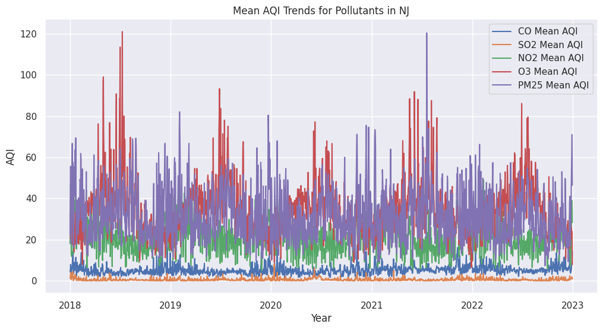

```python
# POLLUTANTS OVER TIME IN NJ
# Filter data for the state of NJ
df_nj = df[df['state'] == 'NJ']

# Set up the plot
plt.figure(figsize=(12, 6))
sns.set_theme(style="darkgrid")

# Plot mean AQI for each pollutant
for pollutant in ['CO', 'SO2', 'NO2', 'O3', 'PM25']:
    sns.lineplot(x='date', y=f'{pollutant}_mean_aqi', label=f'{pollutant} Mean AQI', data=df_nj)

# Add a title, legend, and show the plot
plt.title('Mean AQI Trends for Pollutants in NJ')
plt.legend()
plt.ylabel('AQI')
plt.xlabel('Year')
plt.show()
```

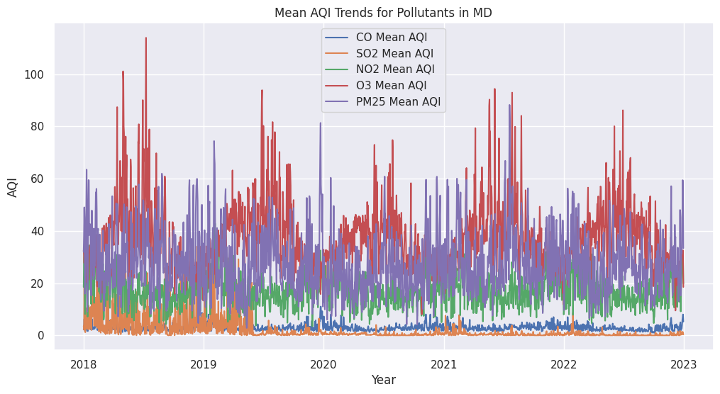

```python
# Filter data for the state of MD
df_md = df[df['state'] == 'MD']

# Set up the plot
plt.figure(figsize=(12, 6))
sns.set_theme(style="darkgrid")

# Plot mean AQI for each pollutant
for pollutant in ['CO', 'SO2', 'NO2', 'O3', 'PM25']:
    sns.lineplot(x='date', y=f'{pollutant}_mean_aqi', label=f'{pollutant} Mean AQI', data=df_md)

# Add a title, legend, and show the plot
plt.title('Mean AQI Trends for Pollutants in MD')
plt.legend()
plt.ylabel('AQI')
plt.xlabel('Year')
plt.show()
```

```python
df = df.sort_values(by='date')
df['month'] = df['date'].dt.month
df['year'] = df['date'].dt.year
df.head()
```

|  | date | CO_mean | CO_mean_aqi | max_CO_value | CO_max_aqi | SO2_mean | SO2_mean_aqi | max_SO2_value | SO2_max_aqi | NO2_mean | ... | max_PM10_value | PM10_max_aqi | PM25_mean | PM25_mean_aqi | max_PM25_value | PM25_max_aqi | state | aqi | year | month |
| --- | --- | --- | --- | --- | --- | --- | --- | --- | --- | --- | --- | --- | --- | --- | --- | --- | --- | --- | --- | --- | --- |
| 4383 | 2018-01-01 | 0.233684 | 2.500000 | 0.3 | 3.0 | 0.737505 | 3.500000 | 19.0 | 27.0 | 13.190476 | ... | NaN | NaN | 4.120000 | 17.200000 | 6.6 | 28.0 | NY | 33.615385 | 2018 | 1 |
| 5113 | 2018-01-01 | 0.195833 | 2.250000 | 0.3 | 3.0 | 1.171498 | 3.500000 | 5.0 | 7.0 | 8.768599 | ... | NaN | NaN | 7.630000 | 31.900000 | 9.5 | 40.0 | MD | 32.500000 | 2018 | 1 |
| 4748 | 2018-01-01 | 0.302397 | 4.333333 | 0.6 | 7.0 | 0.462516 | 1.222222 | 2.7 | 3.0 | 8.171428 | ... | NaN | NaN | 5.435714 | 22.642857 | 7.9 | 33.0 | NJ | 32.000000 | 2018 | 1 |
| 5114 | 2018-01-02 | 0.189583 | 3.250000 | 0.4 | 5.0 | 0.952929 | 2.166667 | 4.0 | 6.0 | 13.254691 | ... | 17.0 | 16.0 | 9.176923 | 38.153846 | 13.4 | 54.0 | MD | 38.153846 | 2018 | 1 |
| 4749 | 2018-01-02 | 0.341667 | 5.000000 | 0.6 | 7.0 | 0.901892 | 1.555556 | 3.6 | 4.0 | 13.569047 | ... | 29.0 | 27.0 | 9.744828 | 40.379310 | 13.6 | 54.0 | NJ | 40.379310 | 2018 | 1 |

5 rows × 29 columns

```python
fig = px.box(df, x='month', y='aqi', color='state',
             labels={'aqi': 'AQI'},
             title='Seasonal Patterns of Max AQI by State')
fig.update_xaxes(tickvals=np.arange(12)+1, ticktext=['Jan', 'Feb', 'Mar', 'Apr', 'May', 'Jun', 'Jul', 'Aug', 'Sep', 'Oct', 'Nov', 'Dec'])
fig.show()
```

[interactive chart not shown]

In order to process in the following machine learning algorithm, we choose to find the correlation between each pollutants.

```python
correlation_matrix = df[['CO_mean_aqi', 'SO2_mean_aqi', 'NO2_mean_aqi', 'O3_mean_aqi', 'PM25_mean_aqi', 'aqi']].corr()
fig = px.imshow(correlation_matrix, labels=dict(color="Correlation"), title='Correlation Heatmap')
fig.show()
```

[interactive chart not shown]

```python
print(df[['CO_mean_aqi', 'SO2_mean_aqi', 'NO2_mean_aqi', 'O3_mean_aqi', 'PM25_mean_aqi']].isna().any())

# Select feature columns
feature_columns = ['CO_mean_aqi', 'SO2_mean_aqi', 'NO2_mean_aqi', 'O3_mean_aqi', 'PM25_mean_aqi']

# Filter rows with NaN values in feature columns
rows_with_nans = df[df[feature_columns].isnull().any(axis=1)]

# Display the resulting DataFrame
print(rows_with_nans)
```

```
CO_mean_aqi       True
SO2_mean_aqi      True
NO2_mean_aqi      True
O3_mean_aqi      False
PM25_mean_aqi     True
dtype: bool
           date  CO_mean  CO_mean_aqi  max_CO_value  CO_max_aqi  SO2_mean  \
3286 2020-03-09      NaN          NaN           NaN         NaN       NaN
3287 2020-03-10      NaN          NaN           NaN         NaN       NaN
2990 2020-03-11     0.25          2.5           0.3         3.0  0.554524

      SO2_mean_aqi  max_SO2_value  SO2_max_aqi   NO2_mean  ...  \
3286           NaN            NaN          NaN        NaN  ...
3287           NaN            NaN          NaN        NaN  ...
2990      0.571429            2.0          3.0  14.465952  ...

      max_PM10_value  PM10_max_aqi  PM25_mean  PM25_mean_aqi  max_PM25_value  \
3286             NaN           NaN        NaN            NaN             NaN
3287            15.0          14.0       4.65           19.5             7.5
2990             NaN           NaN        NaN            NaN             NaN

      PM25_max_aqi  state        aqi  year  month
3286           NaN     MD  45.000000  2020      3
3287          31.0     MD  36.500000  2020      3
2990           NaN     MD  29.421053  2020      3

[3 rows x 29 columns]
```

```python
# # split df into df_train and df_pred

# # Ensure 'date' column is in datetime format
# df['date'] = pd.to_datetime(df['date'])

# # Split the DataFrame based on date ranges
# start_train_date = '2018-01-01'
# end_train_date = '2023-09-30'
# start_pred_date = '2023-10-01'
# end_pred_date = '2023-10-31'

# # Create df_train
# df_train = df[(df['date'] >= start_train_date) & (df['date'] <= end_train_date)]

# # Create df_pred
# df_pred = df[(df['date'] >= start_pred_date) & (df['date'] <= end_pred_date)]
```

## 4 Machine Learning Algorithm

```python
import pandas as pd
from sklearn.model_selection import train_test_split
from sklearn.impute import SimpleImputer
from sklearn.ensemble import RandomForestRegressor

# Select features and target variable
features = ['CO_mean_aqi', 'SO2_mean_aqi', 'NO2_mean_aqi', 'O3_mean_aqi', 'PM25_mean_aqi']
target = 'aqi'

# Create a new DataFrame with selected features and target variable
X = df[features]
y = df[target]

# Split the data into training and testing sets
X_train, X_test, y_train, y_test = train_test_split(X, y, test_size = 0.3, random_state = 1001)

# Impute missing values separately for training and testing sets
imputer = SimpleImputer(strategy='mean')
X_train_imputed = imputer.fit_transform(X_train)
X_test_imputed = imputer.transform(X_test)

# Check for remaining NaN values after imputation in both sets
if pd.DataFrame(X_train_imputed, columns=X.columns).isnull().any().any() or pd.DataFrame(X_test_imputed, columns=X.columns).isnull().any().any():
    raise ValueError("NaN values still present after imputation. Check your data.")

# --------------------------------------------------------------------------------------------------------
# After hyper parameter tuning we find that Random Forest with MSE -> 0.164810 and R2 -> 0.998759 with
# {'max_depth': 20, 'min_samples_leaf': 1, 'min_samples_split': 2, 'n_estimators': 50}
# The code for hyperparameter is commented below, let us create a RF model with best paramters.

# After hyperparameter tuning, create a Random Forest model with the best parameters
best_rf_params = {'max_depth': None, 'min_samples_leaf': 1, 'min_samples_split': 2, 'n_estimators': 100, 'random_state': 42}
good_final_rf_model = RandomForestRegressor(**best_rf_params)

# Fit the model on the training set
good_final_rf_model.fit(X_train_imputed, y_train)


# This predicts aqi giving 5 polutants.
# --------------------------------------------------------------------------------------------------------
# After hyper parameter tuning we find that Random Forest with MSE -> 0.164810 and R2 -> 0.998759 with
# {'max_depth': 20, 'min_samples_leaf': 1, 'min_samples_split': 2, 'n_estimators': 50}
# The code for hyperparameter is commented below, let us create a RF model with best paramters.


# # 1. Linear Regression
# linear_reg = LinearRegression()
# linear_reg.fit(X_train, y_train)

# # 2. Random Forest Regressor
# rf_params = {'n_estimators': [50, 100, 200],
#              'max_depth': [None, 10, 20],
#              'min_samples_split': [2, 5, 10],
#              'min_samples_leaf': [1, 2, 4]}
# rf_grid = GridSearchCV(RandomForestRegressor(), rf_params, cv=5, scoring='neg_mean_squared_error')
# rf_grid.fit(X_train, y_train)

# # 3. Gradient Boosting Regressor
# gb_params = {'n_estimators': [50, 100, 200],
#              'learning_rate': [0.01, 0.1, 0.2],
#              'max_depth': [3, 5, 7]}
# gb_grid = GridSearchCV(GradientBoostingRegressor(), gb_params, cv=5, scoring='neg_mean_squared_error')
# gb_grid.fit(X_train, y_train)

# # Compare models on the test set
# linear_reg_preds = linear_reg.predict(X_test)
# rf_preds = rf_grid.predict(X_test)
# gb_preds = gb_grid.predict(X_test)

# # Evaluate performance
# models = ['Linear Regression', 'Random Forest', 'Gradient Boosting']
# mse_scores = [mean_squared_error(y_test, linear_reg_preds),
#               mean_squared_error(y_test, rf_preds),
#               mean_squared_error(y_test, gb_preds)]

# r2_scores = [r2_score(y_test, linear_reg_preds),
#              r2_score(y_test, rf_preds),
#              r2_score(y_test, gb_preds)]

# results_df = pd.DataFrame({'Model': models, 'MSE': mse_scores, 'R2 Score': r2_scores})
# print(results_df)

# # Pick the best model
# best_model_index = results_df['R2 Score'].idxmax()
# best_model = models[best_model_index]
# print(f"The best model is: {best_model}")
# print(f"MSE: {results_df['MSE'].iloc[best_model_index]}")
# print(f"R2 Score: {results_df['R2 Score'].iloc[best_model_index]}")
# print(f"Best hyperparameters:\n{rf_grid.best_params_}")
```

```
RandomForestRegressor(random_state=42)
```

```python
import pandas as pd
from sklearn.model_selection import train_test_split
from sklearn.ensemble import RandomForestRegressor
from sklearn.impute import SimpleImputer

# Assuming df is your original DataFrame

# Select features and target variable
features = ['NO2_mean_aqi', 'SO2_mean_aqi', 'O3_mean_aqi', 'CO_mean_aqi']
target = 'PM25_mean_aqi'

# Create a new DataFrame with selected features and target variable
X = df[features]
y = df[target]

# Split the data into training and testing sets
X_train, X_test, y_train, y_test = train_test_split(X, y, test_size = 0.3, random_state = 1001)

# Handle missing values in the features using SimpleImputer
imputer = SimpleImputer(strategy='mean')
X_train_imputed = imputer.fit_transform(X_train)
X_test_imputed = imputer.transform(X_test)

# Handle missing values in the target variable using SimpleImputer
y_imputer = SimpleImputer(strategy='mean')
y_train_imputed = y_imputer.fit_transform(y_train.values.reshape(-1, 1)).ravel()
y_test_imputed = y_imputer.transform(y_test.values.reshape(-1, 1)).ravel()

# Create a Random Forest Regressor with the best hyperparameters
best_rf_params = {'max_depth': None, 'min_samples_leaf': 1, 'min_samples_split': 2, 'n_estimators': 100}
pm25_rf_model = RandomForestRegressor(**best_rf_params)

# Fit the model on the training set
pm25_rf_model.fit(X_train_imputed, y_train_imputed)




# # 1. Linear Regression
# linear_params = {'fit_intercept': [True, False], 'positive': [True, False]}
# linear_grid = GridSearchCV(LinearRegression(), linear_params, cv=5, scoring='neg_mean_squared_error')
# linear_grid.fit(X_train, y_train)

# # 2. Random Forest Regression
# rf_params = {'n_estimators': [50, 100, 150], 'max_depth': [None, 10, 20], 'min_samples_split': [2, 5, 10], 'min_samples_leaf': [1, 2, 4]}
# rf_grid = GridSearchCV(RandomForestRegressor(), rf_params, cv=5, scoring='neg_mean_squared_error')
# rf_grid.fit(X_train, y_train)

# # 3. Gradient Boosting Regression
# gb_params = {'n_estimators': [50, 100, 150], 'learning_rate': [0.01, 0.1, 0.2], 'max_depth': [3, 5, 7]}
# gb_grid = GridSearchCV(GradientBoostingRegressor(), gb_params, cv=5, scoring='neg_mean_squared_error')
# gb_grid.fit(X_train, y_train)

# # Compare models on the test set
# linear_preds = linear_grid.predict(X_test)
# rf_preds = rf_grid.predict(X_test)
# gb_preds = gb_grid.predict(X_test)

# # Evaluate performance
# models = ['Linear Regression', 'Random Forest', 'Gradient Boosting']
# mse_scores = [mean_squared_error(y_test, linear_preds),
#               mean_squared_error(y_test, rf_preds),
#               mean_squared_error(y_test, gb_preds)]

# r2_scores = [r2_score(y_test, linear_preds),
#              r2_score(y_test, rf_preds),
#              r2_score(y_test, gb_preds)]

# results_df = pd.DataFrame({'Model': models, 'MSE': mse_scores, 'R2 Score': r2_scores})
# print(results_df)
```

```
RandomForestRegressor()
```

```python
# getting data for New York 8/2023

recent_month_NY = getAllData(36, 20230801, 20230831)

recent_month_list_NY = get_df_list(recent_month_NY)
latest_month_NY = clean_df_list(recent_month_list_NY, 'NY')
```

```python
from sklearn.metrics import mean_squared_error, r2_score
```

```python
import pandas as pd
import matplotlib.pyplot as plt

def predict_and_compare_with_visualization(recent_data, pm25_rf_model, aqi_rf_model):
    # Assuming recent_data is a DataFrame containing data for the last two months

    # Select relevant columns and 'date'
    dff = recent_data[['date', 'CO_mean_aqi', 'SO2_mean_aqi', 'NO2_mean_aqi', 'O3_mean_aqi', 'PM25_mean_aqi']]

    # Create a new column 'aqi' with the maximum of pollutant values
    dff['aqi'] = dff[['CO_mean_aqi', 'SO2_mean_aqi', 'NO2_mean_aqi', 'O3_mean_aqi', 'PM25_mean_aqi']].max(axis=1)

    # Use pm25_rf_model to predict PM25 values
    pm25_pred = pm25_rf_model.predict(dff[['NO2_mean_aqi', 'SO2_mean_aqi', 'O3_mean_aqi', 'CO_mean_aqi']])

    # Update the 'PM25_mean_aqi' column with predicted values
    dff['PM25_mean_aqi'] = pm25_pred

    # Use aqi_rf_model to predict AQI values
    aqi_pred = aqi_rf_model.predict(dff[['CO_mean_aqi', 'SO2_mean_aqi', 'NO2_mean_aqi', 'O3_mean_aqi', 'PM25_mean_aqi']])

    # Create a DataFrame for comparison
    comparison_df = pd.DataFrame({
        'date': dff['date'],
        'Actual_AQI': dff['aqi'],
        'Predicted_AQI': aqi_pred
    })

    # Calculate MSE and R2 score
    mse = mean_squared_error(comparison_df['Actual_AQI'], comparison_df['Predicted_AQI'])
    r2 = r2_score(comparison_df['Actual_AQI'], comparison_df['Predicted_AQI'])

    # Print MSE and R2
    print(f'Mean Squared Error (MSE): {mse}')
    print(f'R-squared (R2): {r2}')

    # Plotting
    plt.figure(figsize=(10, 6))
    plt.plot(comparison_df['date'], comparison_df['Actual_AQI'], label='Actual AQI', marker='o')
    plt.plot(comparison_df['date'], comparison_df['Predicted_AQI'], label='Predicted AQI', marker='o')
    plt.title('Actual vs Predicted AQI')
    plt.xlabel('Date')
    plt.ylabel('AQI')
    plt.legend()
    plt.grid(True)
    plt.xticks(rotation=45)
    plt.tight_layout()
    plt.show()

    return comparison_df
```

```
Mean Squared Error (MSE): 47.292985515360975
R-squared (R2): 0.49817676293228197
```

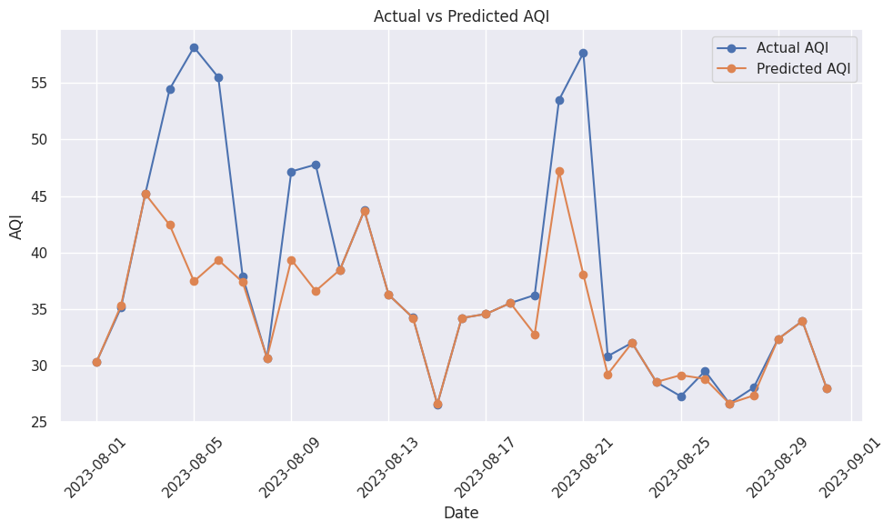

```
         date  Actual_AQI  Predicted_AQI
0  2023-08-01   30.333333      30.317514
1  2023-08-02   35.111111      35.283420
2  2023-08-03   45.185185      45.178991
3  2023-08-04   54.458333      42.431169
4  2023-08-05   58.166667      37.440777
5  2023-08-06   55.500000      39.335624
6  2023-08-07   37.882353      37.371399
7  2023-08-08   30.642857      30.663523
8  2023-08-09   47.166667      39.357864
9  2023-08-10   47.777778      36.591476
10 2023-08-11   38.464286      38.467221
11 2023-08-12   43.714286      43.707596
12 2023-08-13   36.250000      36.248415
13 2023-08-14   34.214286      34.208397
```

[output cut: 17 more lines]

```python
comparison_result = predict_and_compare_with_visualization(latest_month_NY, pm25_rf_model, good_final_rf_model)
print(comparison_result)
```

Here we are getting a new data. using that data we predict a polutant, and then we using polutants given and predicted, we predict aqi.

- Check in the heatmap visualized above, PM2.5 is correlated with aqi, so predicting PM2.5 was a good decision for some complexity.

```python
# getting data for New York 5/2023

recent_month_NY = getAllData(36, 20230501, 20230531)

recent_month_list_NY = get_df_list(recent_month_NY)
latest_month_NY = clean_df_list(recent_month_list_NY, 'NY')
```

```
Mean Squared Error (MSE): 1.6713833565812495
R-squared (R2): 0.9857122858521223
```

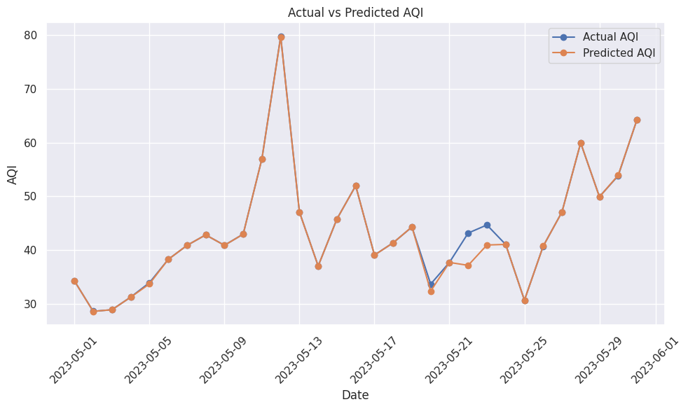

```
         date  Actual_AQI  Predicted_AQI
0  2023-05-01   34.250000      34.251830
1  2023-05-02   28.607143      28.590829
2  2023-05-03   28.892857      28.899070
3  2023-05-04   31.250000      31.232019
4  2023-05-05   33.928571      33.700014
5  2023-05-06   38.250000      38.257652
6  2023-05-07   40.857143      40.859995
7  2023-05-08   42.821429      42.833314
8  2023-05-09   40.892857      40.874428
9  2023-05-10   42.964286      42.958594
10 2023-05-11   57.000000      57.001327
11 2023-05-12   79.750000      79.657044
12 2023-05-13   47.071429      47.047536
13 2023-05-14   37.035714      37.035885
```

[output cut: 17 more lines]

```python
comparison_result = predict_and_compare_with_visualization(latest_month_NY, pm25_rf_model, good_final_rf_model)
print(comparison_result)
```

```python
# getting data for Maryland 5/2023

recent_month_MD = getAllData(24, 20230501, 20230531)

recent_month_list_MD = get_df_list(recent_month_MD)
latest_month_MD = clean_df_list(recent_month_list_MD, 'MD')
```

```
Mean Squared Error (MSE): 2.0778710062702497
R-squared (R2): 0.9800477280769133
```

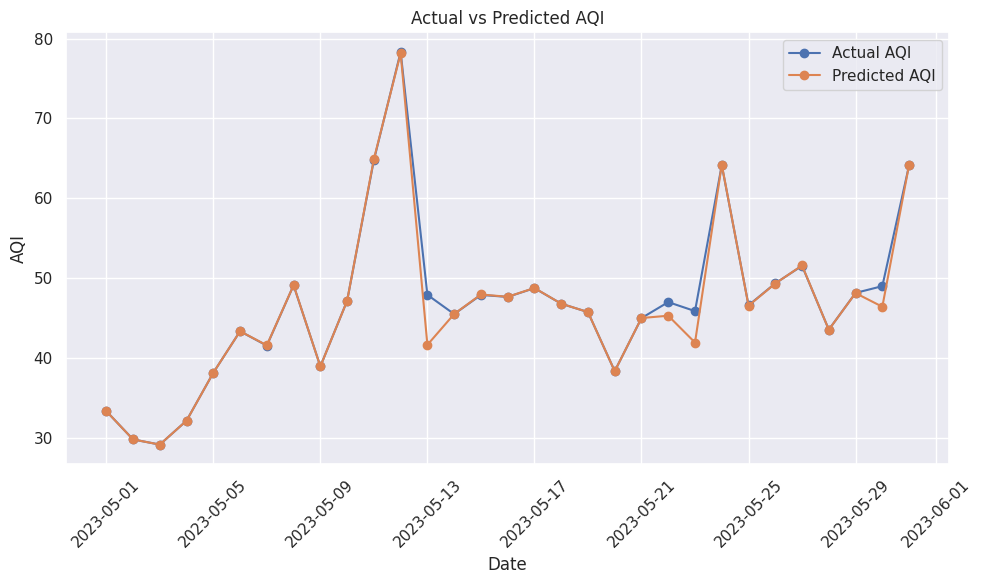

```
         date  Actual_AQI  Predicted_AQI
0  2023-05-01   33.350000      33.350471
1  2023-05-02   29.800000      29.796897
2  2023-05-03   29.150000      29.154440
3  2023-05-04   32.150000      32.148835
4  2023-05-05   38.150000      38.151021
5  2023-05-06   43.350000      43.351180
6  2023-05-07   41.550000      41.585821
7  2023-05-08   49.105263      49.120841
8  2023-05-09   38.947368      38.940305
9  2023-05-10   47.157895      47.155550
10 2023-05-11   64.782609      64.911059
11 2023-05-12   78.333333      78.163303
12 2023-05-13   47.909091      41.645209
13 2023-05-14   45.500000      45.508482
```

[output cut: 17 more lines]

```python
comparison_result = predict_and_compare_with_visualization(latest_month_MD, pm25_rf_model, good_final_rf_model)
print(comparison_result)
```

```python
# getting data for New Jersey 5/2023

recent_month_NJ = getAllData(34, 20230501, 20230531)

recent_month_list_NJ = get_df_list(recent_month_NJ)
latest_month_NJ = clean_df_list(recent_month_list_NJ, 'NJ')
```

```
Mean Squared Error (MSE): 13.913081393161294
R-squared (R2): 0.8795142135730424
```

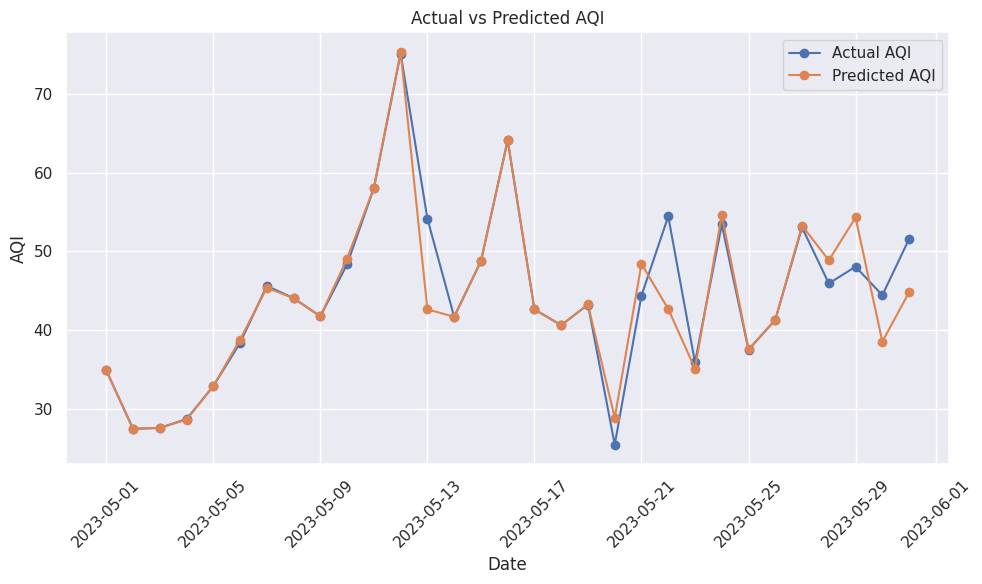

```
         date  Actual_AQI  Predicted_AQI
0  2023-05-01   34.875000      34.880284
1  2023-05-02   27.437500      27.457618
2  2023-05-03   27.562500      27.566135
3  2023-05-04   28.687500      28.615809
4  2023-05-05   32.875000      32.877794
5  2023-05-06   38.375000      38.774737
6  2023-05-07   45.625000      45.388110
7  2023-05-08   44.062500      44.057558
8  2023-05-09   41.750000      41.748045
9  2023-05-10   48.375000      49.105364
10 2023-05-11   58.055556      58.100975
11 2023-05-12   75.166667      75.375006
12 2023-05-13   54.176471      42.643788
13 2023-05-14   41.687500      41.688219
```

[output cut: 17 more lines]

```python
comparison_result = predict_and_compare_with_visualization(latest_month_NJ, pm25_rf_model, good_final_rf_model)
print(comparison_result)
```